# 第6回 整理集計①：地域指標

経済データ入門

第6回

整理集計①：地域指標

都道府県名というキーが 1 本あれば、ばらばらの表は 1 枚になり、  
47 行の山は「約 4 割」という 1 行になる

経済データ入門

第6回 — Topic01

県内総生産と県民所得

その県の数字は、どの範囲を数えたものか

## 前回の振り返り

前回のポイント 第5回「利子と価格②：物価指数」

Q: 値段の動きを、どう 1 つの数にしたか

- **物価指数**：基準の年の値段を 100 と置く
- **買い物かご**：品目の値段を、ウェイトでまとめる
- **実質**：名目を物価指数で割り、100 を掛ける

今日の相手は、国や自治体が作った 47 行の表

## この回の道のりと「地域」シート

1

出所と範囲

2

取り込みと型

演習 6-1

文字にした東京都

3

キーで結合

演習 6-2

地域ブロック

4

並べて絞る

演習 6-3

大阪府の 1 人当たり

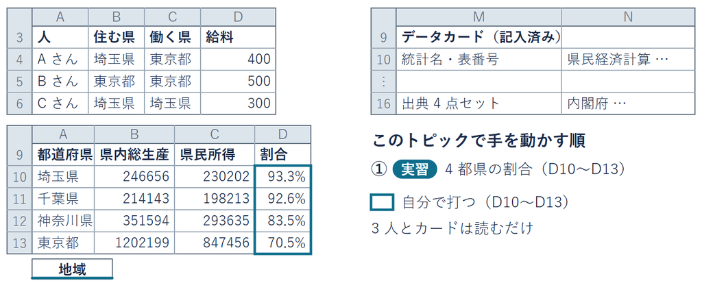

置き場は lec6-exercise.xlsx の「地域」シート

## たしかめ 給料が入る県

前の回までは、国全体の数（物価・金利）を見てきた  
今度は、自分の出身県の経済が大きいほうかを比べたい  
埼玉県に住み、東京都の会社で働く人がいる  
その給料は、どちらの県の数字に入るか

1

**東京都の数字**

2

**埼玉県の数字**

1 つ決めてから先へ。答えは、このトピックの中で出す

## 働く場所で数える給料

[figure not shown]

**サンプルデータ**：説明用の架空の 3 人  
（lec6-exercise.xlsx「地域」の A3:D6）

働く県で箱を決めると、東京都 900・埼玉県 300

## 住む場所で数える給料

[figure not shown]

**サンプルデータ**：同じ 3 人（lec6-exercise.xlsx「地域」の A3:D6）

住む県で箱を決めると、東京都 500・埼玉県 700

## 県内総生産と県民所得

用語

**県内総生産**：その県の中で生み出された額

**県民所得**：その県に住む人と企業が受け取った額

- **県内総生産**：働く場所で数える。会社や工場の集まり方を見る
- **県民所得**：住む場所で数える。住む人の受け取りに近い
- **給料**：どちらにも入る、全体の一部
- **A さんの 400 万円**：東京都の県内総生産と、埼玉県の県民所得

最初の問いの答えは 1 と 2 の両方。  
どちらの数字を見るかで、入る県が変わる

## 県民経済計算

今度は、県民経済計算の本物の数で、同じ 2 つを見る

用語

**県民経済計算**：県ごとの経済の大きさを  
国の GDP と同じ考え方で推計した統計

- **作成機関**：内閣府。各都道府県の推計を取りまとめる
- **年度**：4月〜翌年3月の 1 年。この回は令和4年度（2022年度）
- **単位**：億円。2 つの列は県内総生産と県民所得
- **量の感覚**：東京都の県内総生産 1,202,199 億円は約 120 兆円

## たしかめ 県民所得の割合

県民所得 ÷ 県内総生産が大きいのは、埼玉県と東京都のどちらか

| 都道府県 | 県内総生産（億円） | 県民所得（億円） |
| --- | --- | --- |
| 埼玉県 | 246,656 | 230,202 |
| 千葉県 | 214,143 | 198,213 |
| 神奈川県 | 351,594 | 293,635 |
| 東京都 | 1,202,199 | 847,456 |

**出典**：内閣府「県民経済計算」令和4年度・「地域」の A9:C13

**1 埼玉県のほうが大きい**

**2 東京都のほうが大きい**

## 4 都県の割合の式

1. **式**：D10 に `=C10/B10`  
   県民所得 ÷ 県内総生産
2. **引く**：D10 をもう一度選び  
   フィルハンドルを D13 まで
3. **見る**：D13 が 70.5%  
   （% の書式は印刷済み）

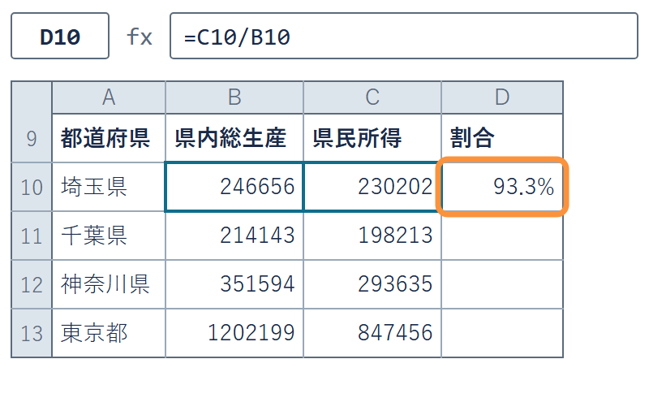

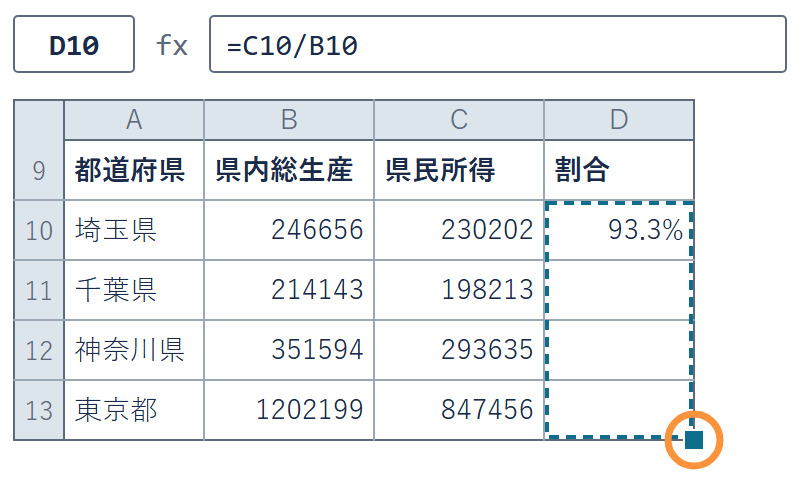

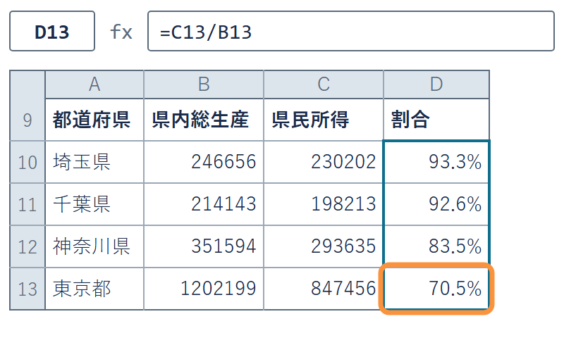

lec6-exercise.xlsx の D10〜D13。93.3%・92.6%・83.5%・70.5% と並ぶ

✋ 動画を止めて STEP 1〜3 を進め、D13 が 70.5% なら再生に戻る

## 4 都県の割合

[figure not shown]

- **出典**：内閣府「県民経済計算」令和4年度
- **100% 未満**：47 の合計でも 72.3%

東京都の隣の 3 県は高く、東京都は 70.5%。答えは 1 番

## 失敗例 県内と県民の取り違え

列を取り違える  
「東京都の県民所得は  
1,202,199 億円」  
これは県内総生産の値

列の名前と年度を添える  
「東京都・令和4年度  
県内総生産は 1,202,199 億円  
県民所得は 847,456 億円」

- **なぜ起きるか**：名前が 1 字ちがいで、表の列が隣り合う
- **差は大きい**：1,202,199 − 847,456 ＝ 354,743 億円（約 35 兆円）
- **どう防ぐか**：列の名前をそのまま写し、年度を添える

## 県民経済計算のデータカード

| 欄 | 県民経済計算のカード（記入済み） |
| --- | --- |
| 統計名・表番号 | 県民経済計算 総括表（県内総生産・県民所得・人口） |
| 作成機関 | 内閣府（各都道府県の推計を取りまとめる） |
| 調査の種類 | **加工統計**・年度ごと（4月〜翌年3月） |
| 単位・基準 | **億円**（公表は百万円）・名目 |
| 定義の落とし穴 | 令和5年度は 5 県が空欄・47 の合計は国の GDP と一致しない・ 基準年改定で過去の値が変わる |
| 入手先・取得日 | 内閣府のページ・2026年9月22日 |
| 出典 4 点セット | 内閣府「県民経済計算（平成23年度－令和4年度）」総括表 令和4年度（2022年度）、2026年9月22日取得 |

欄は前の回と同じ 7 つ。ブックの M9〜N16 に記入済み

## まとめ

- **県内総生産**：その県の中で生み出された額。働く場所で数える
- **県民所得**：その県に住む人と企業が受け取った額。住む場所で数える
- **4 都県では**：埼玉県 93.3%・東京都 70.5%
- **書くとき**：列の名前と年度を添える

47 県ぶんの数は CSV で届く。そのまま計算できるのか  
これを次のトピックで見る

経済データ入門

第6回 — Topic02

データ型と CSV の取り込み —  
Power Query

文字の数字は、SUM の合計に入らない

## この回の道のりと「地域」シート

1

出所と範囲

2

取り込みと型

演習 6-1

文字にした東京都

3

キーで結合

演習 6-2

地域ブロック

4

並べて絞る

演習 6-3

大阪府の 1 人当たり

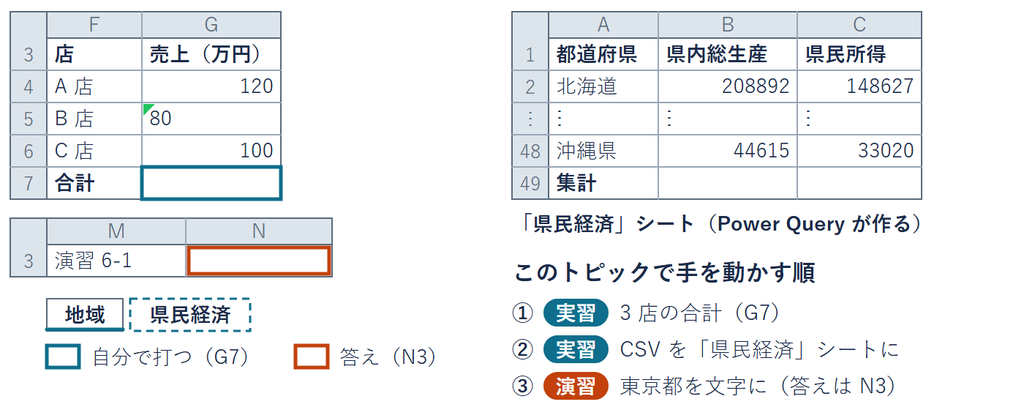

「地域」の G7・N3 と、Power Query が作る「県民経済」シート

## CSV で数える 3 つの項目

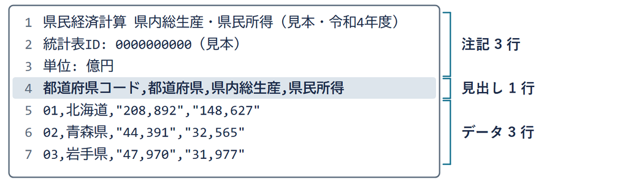

- **行数**：7 行（注記 3・見出し 1・データ 3）
- **列名**：4 つ（コード・都道府県・県内総生産・県民所得）
- **文字コード**：シフト JIS。合わないと日本語が化ける

**サンプルデータ**：CSV の形を見るための見本（3 県ぶん）

見出しは 4 行目。数は引用符とカンマつき

## たしかめ 3 店の売上の合計

80 のセルだけ左寄せで、左上に緑の三角がある  
G7 に `=SUM(G4:G6)` と打つと、いくつになるか

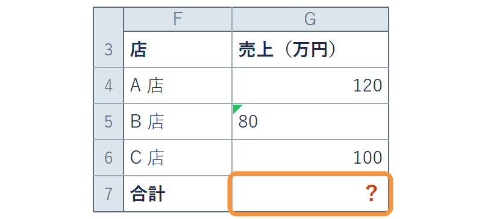

A

**300**

B

**220**

C

**エラーが出る**

**サンプルデータ**：説明用の架空の 3 店（lec6-exercise.xlsx「地域」の F3:G6）

## 文字の 80 と SUM の合計

[figure not shown]

**サンプルデータ**：同じ 3 店（lec6-exercise.xlsx「地域」の F3:G6）

SUM は文字の 80 を飛ばし、合計は 220. 答えは B

## 型

用語

**型**：その値を、数値と見るか文字と見るかの区別

- **文字の数字**：設定を変えていなければ、  
  左寄せで左上に緑の三角（注意の印）
- **SUM と集計行**：文字のセルを飛ばす。＋でつなぐと数として足す
- **困る所**：答えはエラーにならず、80 少ない合計のまま進む
- **確かめ方**：合計が、正解の数と合うかを見る

見た目が同じ 80 でも、型が違えば合計が変わる

## 3 店の合計の式

1. **式**：G7 に `=SUM(G4:G6)`  
   合計は 220
2. **直す**：G5 を選び、横の ! の印から  
   「数値に変換する」
3. **見る**：G7 が 300  
   （式は打ち直さない）

[figure not shown]

[figure not shown]

[figure not shown]

80 が右寄せになり、G7 の合計は 300

✋ 動画を止めて STEP 1〜3 を進め、G7 が 300 なら再生に戻る

## 県民経済計算の CSV

今度は、47 県ぶんの CSV で、見出しの位置と型を見る

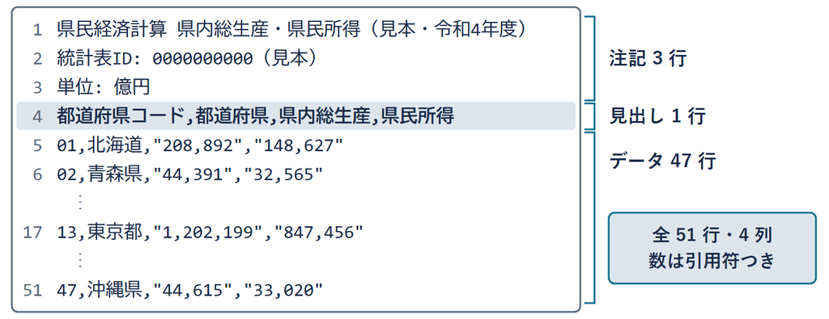

- **出典**：内閣府「県民経済計算」令和4年度。注記の 3 行は見本の形
- **置き場**：配布の lec6-kenmin.csv（文字コードはシフト JIS）

## Power Query による取り込み

用語

**Power Query**：表を整える操作を、手順として記録する機能

- **開くだけでは**：注記 3 行のぶん、見出しが 4 行目にずれる
- **手で直すと**：毎月同じ形の CSV が届くたびに、同じ直しをする
- **Power Query なら**：見出し・型・列の直し方が、このブックに残る

直した結果ではなく、直し方を残す

## 取り込みの手順

1. **取り込む**：「データ」→「テキストまたは CSV から」で lec6-kenmin.csv
2. **変換へ**：文字化けを確かめ、「データの変換」を押す
3. **見出しを決める**：上位の行を 3 行削除し、1 行目を見出しに
4. **列を消す**：都道府県コードの列を削除
5. **型を確かめる**：金額 2 列の印が 1²3 なら次へ。ABC なら「整数」に
6. **閉じる**：名前を 県民経済 にして「閉じて読み込む」

STEP は 6 つ。次の 3 ページの丸の番号が STEP

## STEP 1・2 データの変換

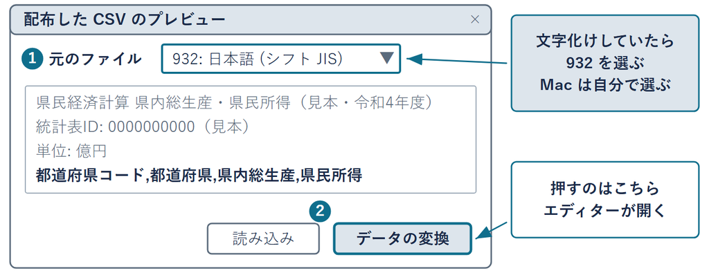

押すのは「データの変換」。Power Query エディターが開く

Mac は「データ」→「データ ファイル指定 (Power Query)」が入口

## STEP 3 見出し行の決定

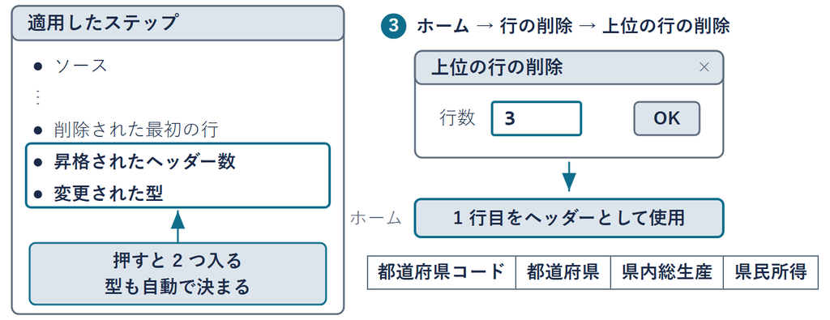

上の 3 行の注記を捨て、残った 1 行目を見出しにする  
押しすぎたら、一番下のステップを × で消す

Mac は「変換」タブ。右の欄は「適用されたステップ」

## STEP 4・5 列の削除と型の確かめ

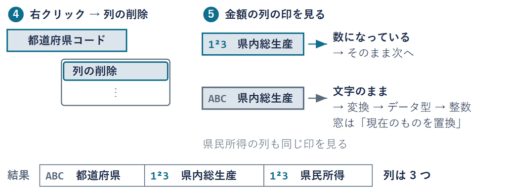

Power Query では、型は列ごとに決まる。  
1²3 は整数、ABC は文字

2 列は Ctrl＋クリックで選ぶ。Mac は ⌘＋クリック

## 県民経済の表の取り込み

1. **整える**：ここまでの  
   5 つの STEP で整える
2. **閉じる**：名前を 県民経済 にして  
   「閉じて読み込む」
3. **見る**：「テーブル デザイン」で  
   集計行をオン。B49 を選び  
   ▼ で「合計」  
   Mac は「テーブル」タブ

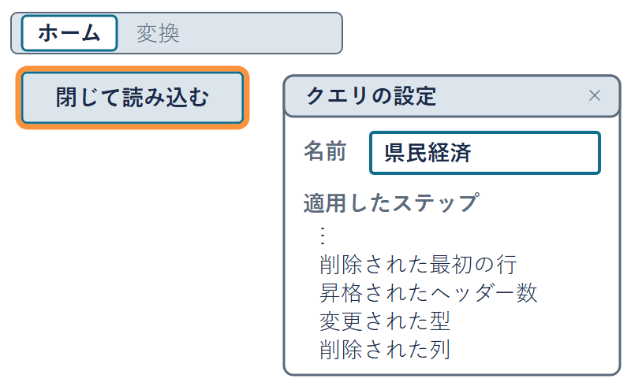

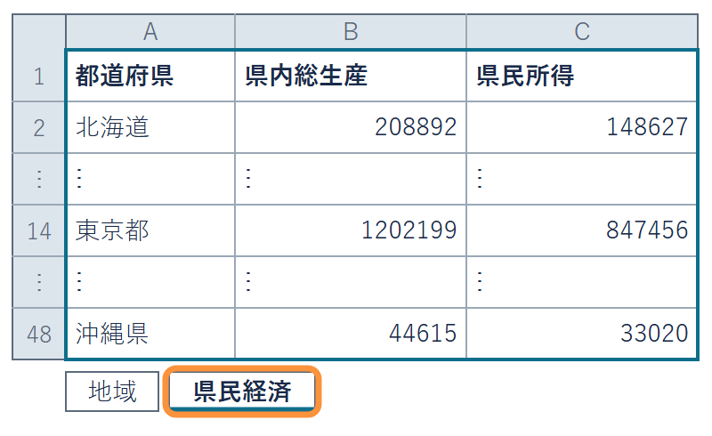

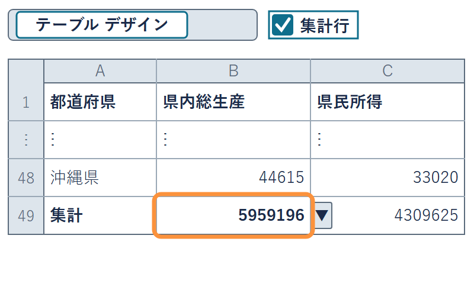

新しいシート「県民経済」に 47 行。合計は 5,959,196 億円

✋ 動画を止めて ①〜③ を進め、B49 が 5959196 なら再生に戻る

## 失敗例 型の直し忘れ

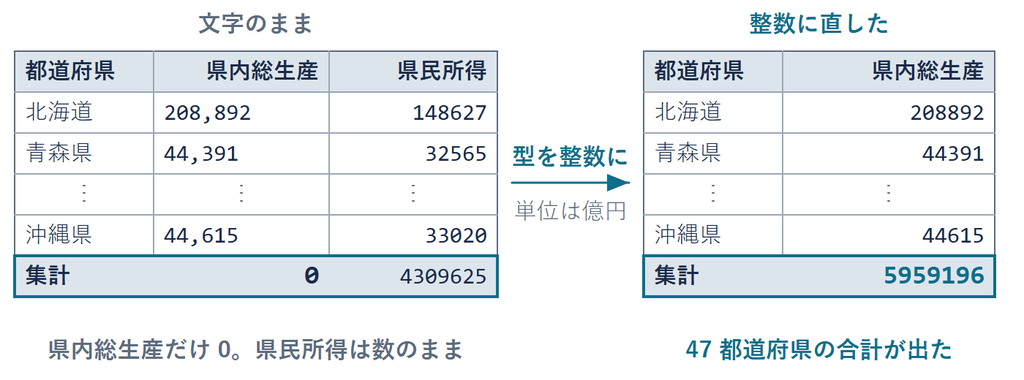

- **起きるとき**：金額の列が ABC のまま「閉じて読み込む」
- **戻り道**：「データ」→「データの取得」の ▼ →  
  「Power Query エディターの起動」
- **直すのは 1 か所**：型を「整数」にして、もう一度「閉じて読み込む」

Mac は「データ ファイル指定 (Power Query)」の ▼ から同じ所へ

## 適用したステップとすべて更新

用語

**適用したステップ**：行った操作を、上から順に残した一覧

**すべて更新**：その一覧を、上から丸ごとやり直す

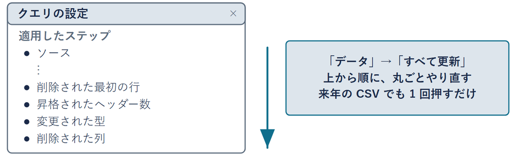

Mac の名前：削除された上位の行・変更された列タイプ

直し方が残っているから、同じ結果をもう一度出せる

## 演習 6-1 文字にした東京都

演習 6-1

東京都の県内総生産だけが文字なら、集計行はいくつか

1. **変える場所**：「県民経済」の B14（東京都）に `'1202199` と打つ
2. **考える問い**：B49 は 0 か、別の数か。先に予想する
3. **書く**：B49 の数を、「地域」の N3 に値で打つ
4. **戻す**：「データ」→「すべて更新」で B14 を元に戻す

先頭の `'` は半角。数字を文字として入れる印

✋ 動画を止めて 3 分。N3 に打ち、すべて更新で戻したら再生に戻る

## 演習 6-1 の答えの例

| セル | 元のまま | B14 を文字に |
| --- | --- | --- |
| B14 東京都 | 1202199（数値・右寄せ） | 1202199（文字・左寄せ） |
| B49 集計 | 5959196 | **4756997** |

- **N3**：4756997 を打ち、すべて更新で B14 を戻す
- **0 にならない**：文字の B14 だけ飛ばし、残り 46 県を足す
- **差**：5,959,196 − 4,756,997 ＝ 1,202,199（東京都の分）

## まとめ

- **型**：数値か文字か。SUM と集計行は、文字の数字を飛ばす。  
  答えはエラーにならない
- **確かめ方**：行数 47 と、集計行の合計 5,959,196 を見る
- **Power Query**：直し方が残り、すべて更新でやり直せる

県民経済の表ができた。人口は別の表にあり、並び順も違う  
これを次のトピックで見る

経済データ入門

第6回 — Topic03

キーによる表の結合 — XLOOKUP

並び順が違う表から、正しい行を引く

## この回の道のりと「地域」シート

1

出所と範囲

2

取り込みと型

演習 6-1

文字にした東京都

3

キーで結合

演習 6-2

地域ブロック

4

並べて絞る

演習 6-3

大阪府の 1 人当たり

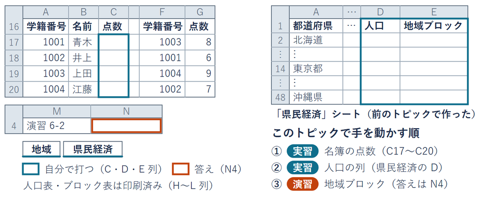

「地域」の C17〜C20・N4 と、「県民経済」の D 列・E 列

## 並び順の違う 2 つの表

県民経済の表に、47 県の県内総生産と県民所得がそろった  
関東の県を、住む人の多さと並べて比べたい。人口は別の表にある  
並び順の違う表から、同じ県の数だけを横へ持ってこられないか

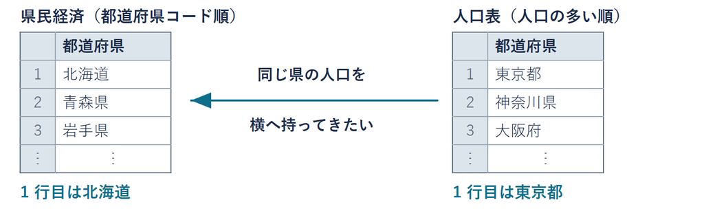

人口表は人口の多い順。まず、4 人の名簿で考える

## たしかめ 名簿に貼った点数

点数の列をコピーして、名簿の C17〜C20 に貼る  
青木さんの行に入るのは、どれか

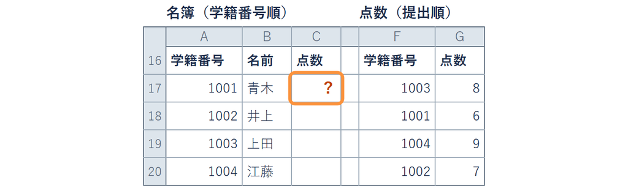

A

**青木さんの点**

B

**別の人の点**

C

**エラーが出る**

**サンプルデータ**：架空の名簿（lec6-exercise.xlsx の A16:G20）

## 名簿に貼った点数

[figure not shown]

**サンプルデータ**：同じ 4 人（lec6-exercise.xlsx の A16:G20）

貼ると、学籍番号ではなく行の順で合わせる。答えは B

## 目でやる 3 歩

[figure not shown]

**サンプルデータ**：同じ表（lec6-exercise.xlsx の F16:G20）

人の目は、学籍番号を目印に探し、同じ行の点数を取っている

## キーと検索値

用語

**キー**：行を 1 つに決める、重複しない目印の列

**検索値**：探すもの。この行の学籍番号

**検索範囲**：キーが並んだ列。点数の表の学籍番号

**戻り範囲**：取りたい列。点数の表の点数

- **キーの例**：学籍番号・商品コード・都道府県名
- **名前ではない理由**：同名が 2 人なら、最初の 1 人だけ返る

探す列と取る列が違うので、範囲は 2 つ書く

## XLOOKUP の式

目でやる「探す → 横へ → 取る」を、Excel にやらせる関数

公式

`=XLOOKUP(検索値, 検索範囲, 戻り範囲)`

今回は `=XLOOKUP([@学籍番号], 点数[学籍番号], 点数[点数])`

- **青木さんの行**：1001 で点数の表を探し、同じ行の 6 を返す
- **`[@学籍番号]`**：同じ行の学籍番号。前に出てきた書き方
- **使える版**：Microsoft 365 と Excel 2021 以降
- **使えない人は**：大学の PC か Excel オンラインで実習

## 名簿の点数の式

1. **式**：C17 に XLOOKUP の式  
   （数式バーのとおり）
2. **広がる**：Enter で C20 まで  
   同じ式が入る
3. **見る**：C17 の 6 は、点数の表の  
   1001 の行の 6

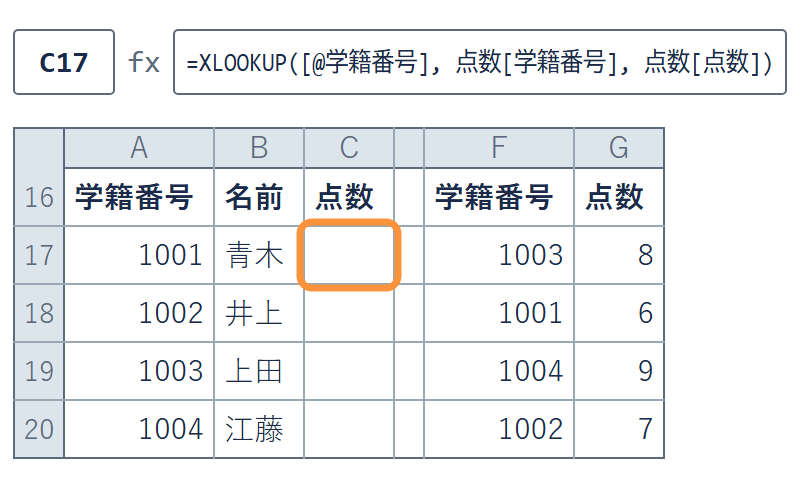

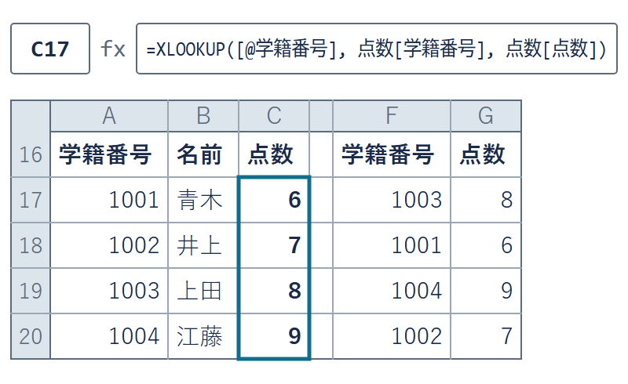

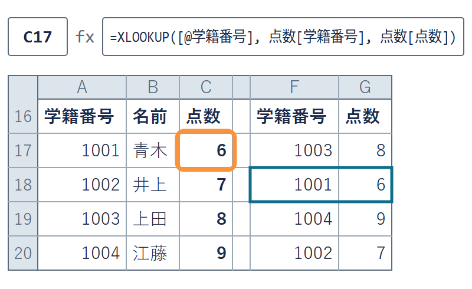

lec6-exercise.xlsx「地域」の C17〜C20 が 6・7・8・9

✋ 動画を止めて STEP 1〜3 を進め、C20 が 9 なら再生に戻る

## 見つからないときの印

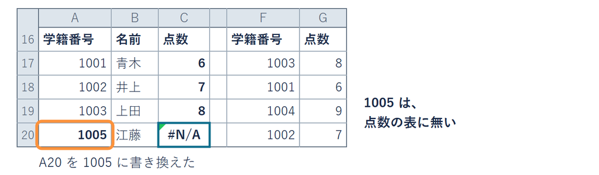

用語

**`#N/A`**：検索値が、検索範囲に見つからなかった印

1005 は点数の表に無い。ほかの 3 人は引けたまま  
試したら、A20 を 1004 に戻す

## 人口表に貼った人口

今度は 47 県で、同じ手順を  
人口表は lec6-exercise.xlsx「地域」の H16:I63

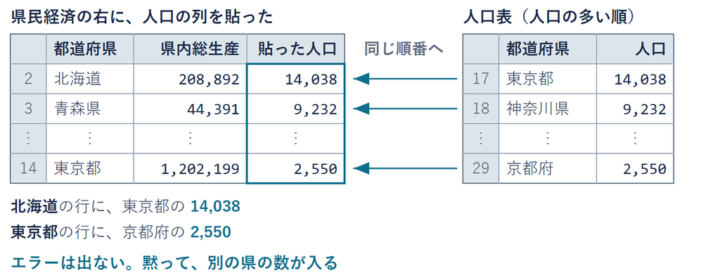

**出典**：内閣府「県民経済計算」総括表9（総人口・千人）・令和4年度

## 人口の列の式

1. **式**：「県民経済」の D1 に 人口  
   D 列に表の色が付いたら  
   D2 に人口表の XLOOKUP
2. **見る**：Enter で 47 行に広がり  
   D14（東京都）が 14038
3. **わざと**：A14 を「東京」にして  
   D14 を見たら、東京都に戻す

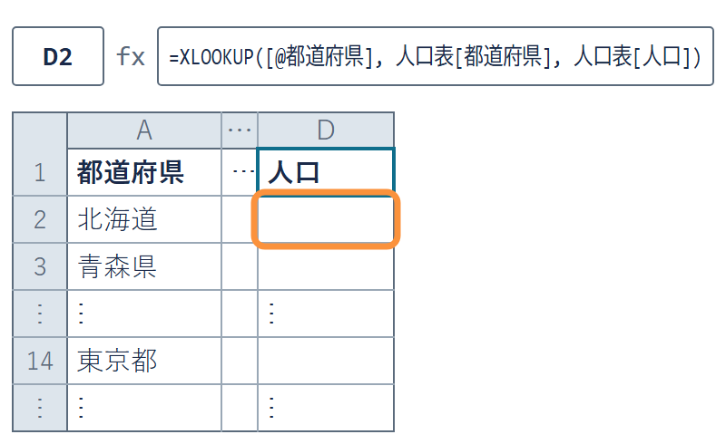

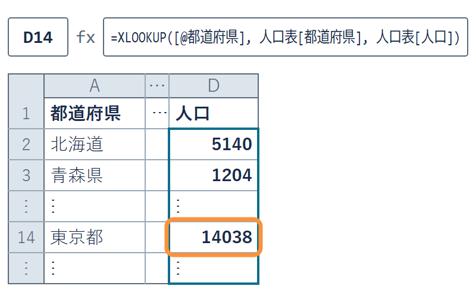

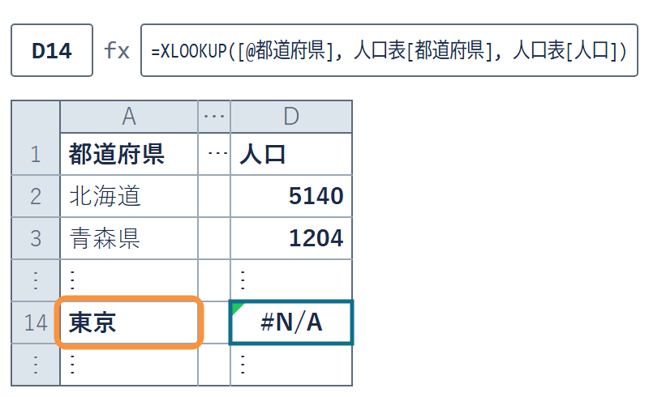

列の名前で指すので、`$` で留めなくても行がずれない

✋ 動画を止めて STEP 1〜3 を進め、A14 を東京都に戻したら再生に戻る